# 474198

## 注意

本项目代码包含多个文件, Fork并使用GPU环境来运行后, 才能看到项目完整代码, 并正确运行:

[figure not shown]

并请检查相关参数设置, 例如use_gpu, fluid.CUDAPlace(0)等处是否设置正确.

## 简介

区域卷积神经网络（RCNN）系列模型为两阶段目标检测器。通过对图像生成候选区域，提取特征，判别特征类别并修正候选框位置。 RCNN系列目前包含两个代表模型：Faster RCNN，Mask RCNN

[Faster RCNN](https://arxiv.org/abs/1506.01497) 整体网络可以分为4个主要内容：

1. 基础卷积层。作为一种卷积神经网络目标检测方法，Faster RCNN首先使用一组基础的卷积网络提取图像的特征图。特征图被后续RPN层和全连接层共享。本示例采用[ResNet-50](https://arxiv.org/abs/1512.03385)作为基础卷积层。
2. 区域生成网络(RPN)。RPN网络用于生成候选区域(proposals)。该层通过一组固定的尺寸和比例得到一组锚点(anchors), 通过softmax判断锚点属于前景或者背景，再利用区域回归修正锚点从而获得精确的候选区域。
3. RoI Align。该层收集输入的特征图和候选区域，将候选区域映射到特征图中并池化为统一大小的区域特征图，送入全连接层判定目标类别, 该层可选用RoIPool和RoIAlign两种方式，在config.py中设置roi_func。
4. 检测层。利用区域特征图计算候选区域的类别，同时再次通过区域回归获得检测框最终的精确位置。

[Mask RCNN](https://arxiv.org/abs/1703.06870) 扩展自Faster RCNN，是经典的实例分割模型。

Mask RCNN同样为两阶段框架，第一阶段扫描图像生成候选框；第二阶段根据候选框得到分类结果，边界框，同时在原有Faster RCNN模型基础上添加分割分支，得到掩码结果，实现了掩码和类别预测关系的解藕。

本例采用COCO数据集的子集，即随机从COCO大数据集中选取30张图组成coco30数据集,数据存放在rcnn/coco30。 本例采用coco30，可通过修改--data_dir修改训练集.

## Mask RCNN结构图如下：

[figure not shown]

注：本例默认用GPU运行，也可通过设置--use_gpu=False使用CPU设备。

阅读本项目之前建议阅读mask-rcnn**原版论文**https://arxiv.org/abs/1703.06870 **相关优秀博客**https://blog.csdn.net/WZZ18191171661/article/details/79453780

本例采用COCO数据集的子集，即随机从COCO大数据集中选取30张图组成coco30数据集,数据存放在rcnn/coco30。 本例采用coco30，可通过修改--data_dir修改训练集.

**COCO数据集介绍**：https://blog.csdn.net/wc781708249/article/details/79603522

文件夹介绍：

1.models：构造模型主体的函数

2.coco30: 训练数据集

3.output: 保存训练模型

4:imagenet_resnet50_fusebn: 存放预训练模型

所有执行文件均在mask-rcnn文件夹内，在了解mask-rcnn基本原理的基础上，建议阅读顺序：

1.models文件夹：存放模型主体构造以及loss构造相关文件。

2.utility.py、config.py: 训练相关参数设置。

3.readers.py: 训练数据格式构造。

4.train.py：训练主体程序。

5.其他相关辅助函数

```python
#安装CocoAPI
#!git clone https://github.com/cocodataset/cocoapi.git
!cd cocoapi/PythonAPI && make install
```

[output not shown]

[output cut: 70 more lines]

[output not shown]

```python
#模型训练
!cd mask-rcnn && python train.py \
   --model_save_dir=output/ \
   --pretrained_model=imagenet_resnet50_fusebn \
   --data_dir=coco30 \
   --max_iter=3000 \
   --use_gpu=True \
   --MASK_ON=True
```

```
-----------  Configuration Arguments -----------
MASK_ON: 1
anchor_sizes: [32, 64, 128, 256, 512]
aspect_ratios: [0.5, 1.0, 2.0]
batch_size_per_im: 512
class_num: 81
data_dir: coco30
dataset: coco2017
draw_threshold: 0.8
enable_ce: False
freeze_model_save_dir: freeze_model
im_per_batch: 1
image_path: dataset/coco/val2017
learning_rate: 0.01
log_window: 20
max_iter: 3000
max_size: 1333
model_save_dir: output/
nms_thresh: 0.5
padding_minibatch: False
parallel: False
pixel_means: [102.9801, 115.9465, 122.7717]
pretrained_model: imagenet_resnet50_fusebn
rpn_nms_thresh: 0.7
rpn_stride: [16.0, 16.0]
scales: [800]
score_thresh: 0.05
snapshot_stride: 10000
use_gpu: 1
use_profile: False
use_pyreader: False
variance: [1.0, 1.0, 1.0, 1.0]
------------------------------------------------
W1227 10:29:20.776507   215 device_context.cc:235] Please NOTE: device: 0, CUDA Capability: 70, Driver API Version: 9.2, Runtime API Version: 9.0
W1227 10:29:20.782367   215 device_context.cc:243] device: 0, cuDNN Version: 7.3.
Creating: coco2017
loading annotations into memory...
Done (t=0.00s)
creating index...
index created!
```

[output cut: 51 more lines]

```
2019-12-27 10:42:36.496332, iter: 2250, lr: 0.01000, 'loss': 0.869, 'loss_cls': 0.318, 'loss_bbox': 0.227, 'loss_rpn_cls': 0.035, 'loss_rpn_bbox': 0.041, 'loss_mask': 0.228, time: 0.363
2019-12-27 10:42:54.696989, iter: 2300, lr: 0.01000, 'loss': 0.751, 'loss_cls': 0.257, 'loss_bbox': 0.201, 'loss_rpn_cls': 0.016, 'loss_rpn_bbox': 0.033, 'loss_mask': 0.23, time: 0.362
2019-12-27 10:43:12.598901, iter: 2350, lr: 0.01000, 'loss': 0.879, 'loss_cls': 0.285, 'loss_bbox': 0.25, 'loss_rpn_cls': 0.026, 'loss_rpn_bbox': 0.036, 'loss_mask': 0.27, time: 0.354
2019-12-27 10:43:30.635760, iter: 2400, lr: 0.01000, 'loss': 0.834, 'loss_cls': 0.252, 'loss_bbox': 0.199, 'loss_rpn_cls': 0.023, 'loss_rpn_bbox': 0.038, 'loss_mask': 0.238, time: 0.356
2019-12-27 10:43:48.693036, iter: 2450, lr: 0.01000, 'loss': 0.666, 'loss_cls': 0.2, 'loss_bbox': 0.184, 'loss_rpn_cls': 0.023, 'loss_rpn_bbox': 0.034, 'loss_mask': 0.257, time: 0.348
2019-12-27 10:44:06.663519, iter: 2500, lr: 0.01000, 'loss': 0.844, 'loss_cls': 0.29, 'loss_bbox': 0.236, 'loss_rpn_cls': 0.024, 'loss_rpn_bbox': 0.039, 'loss_mask': 0.267, time: 0.358
2019-12-27 10:44:24.903318, iter: 2550, lr: 0.01000, 'loss': 0.781, 'loss_cls': 0.278, 'loss_bbox': 0.228, 'loss_rpn_cls': 0.021, 'loss_rpn_bbox': 0.031, 'loss_mask': 0.249, time: 0.342
2019-12-27 10:44:42.719216, iter: 2600, lr: 0.01000, 'loss': 0.512, 'loss_cls': 0.128, 'loss_bbox': 0.15, 'loss_rpn_cls': 0.014, 'loss_rpn_bbox': 0.03, 'loss_mask': 0.243, time: 0.365
2019-12-27 10:45:00.848790, iter: 2650, lr: 0.01000, 'loss': 0.683, 'loss_cls': 0.174, 'loss_bbox': 0.179, 'loss_rpn_cls': 0.017, 'loss_rpn_bbox': 0.032, 'loss_mask': 0.214, time: 0.358
2019-12-27 10:45:18.855093, iter: 2700, lr: 0.01000, 'loss': 0.698, 'loss_cls': 0.179, 'loss_bbox': 0.187, 'loss_rpn_cls': 0.017, 'loss_rpn_bbox': 0.029, 'loss_mask': 0.229, time: 0.367
2019-12-27 10:45:36.789198, iter: 2750, lr: 0.01000, 'loss': 0.615, 'loss_cls': 0.158, 'loss_bbox': 0.144, 'loss_rpn_cls': 0.021, 'loss_rpn_bbox': 0.036, 'loss_mask': 0.231, time: 0.399
2019-12-27 10:45:54.884990, iter: 2800, lr: 0.01000, 'loss': 0.535, 'loss_cls': 0.162, 'loss_bbox': 0.148, 'loss_rpn_cls': 0.016, 'loss_rpn_bbox': 0.019, 'loss_mask': 0.191, time: 0.352
2019-12-27 10:46:12.821197, iter: 2850, lr: 0.01000, 'loss': 0.601, 'loss_cls': 0.167, 'loss_bbox': 0.142, 'loss_rpn_cls': 0.02, 'loss_rpn_bbox': 0.028, 'loss_mask': 0.201, time: 0.362
2019-12-27 10:46:31.010737, iter: 2900, lr: 0.01000, 'loss': 0.617, 'loss_cls': 0.154, 'loss_bbox': 0.203, 'loss_rpn_cls': 0.015, 'loss_rpn_bbox': 0.028, 'loss_mask': 0.194, time: 0.362
2019-12-27 10:46:49.066869, iter: 2950, lr: 0.01000, 'loss': 0.599, 'loss_cls': 0.16, 'loss_bbox': 0.176, 'loss_rpn_cls': 0.015, 'loss_rpn_bbox': 0.021, 'loss_mask': 0.209, time: 0.511
```

```python
#固化模型
!cd mask-rcnn && python freeze_model.py \
                   --pretrained_model=output/model_final \
                   --freeze_model_save_dir=freeze_model \
                   --use_gpu=1
```

```
The COCO dataset or COCO API is not exist, use the default mapping of class index and real category name on COCO17.
W1227 10:54:47.269948   307 device_context.cc:235] Please NOTE: device: 0, CUDA Capability: 70, Driver API Version: 9.2, Runtime API Version: 9.0
W1227 10:54:47.274207   307 device_context.cc:243] device: 0, cuDNN Version: 7.3.
freeze succeed
```

```
The COCO dataset or COCO API is not exist, use the default mapping of class index and real category name on COCO17.
W1227 10:54:56.312969   367 device_context.cc:235] Please NOTE: device: 0, CUDA Capability: 70, Driver API Version: 9.2, Runtime API Version: 9.0
W1227 10:54:56.319056   367 device_context.cc:243] device: 0, cuDNN Version: 7.3.
image with bbox drawed saved as 000000005802.jpg
```

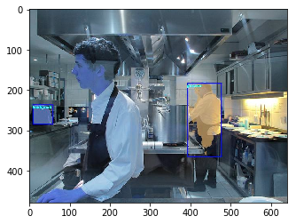

```python
#利用固化的模型进行预测
!cd mask-rcnn && python freeze_infer.py \
                  --image_path=coco30/train2017/000000005802.jpg  \
                  --draw_threshold=0.7 \
                  --use_gpu=1

######检测结果可视化
%matplotlib inline
import matplotlib.pyplot as plt
import numpy as np
import cv2

detect_img= cv2.imread('mask-rcnn/000000005802.jpg')

plt.imshow(detect_img)
plt.show()
```